# Coancestry

J. Ignacio Lucas Lledó

2025-07-16

# Relatedness or coancestry

Relatedness between individuals consists on the sharing of alleles identical by descent (IBD). It is not observable directly, but it can be estimated from genotypes. Between two diploid individuals there are different ways of sharing any pair of alleles IBD. Cockerham (1971) defined 15 probabilities, for the 15 different patterns of IBD in one locus between two diploid individuals. Jacquard (1970) used only 9 such parameters, because he did not distinguish paternal from maternal alleles. In the absence of inbreeding, the two alleles in one individual cannot be IBD, an the number of parameters reduces to three, commonly refered to as $K_2$, $K_1$ and $K_0$, which are the probabilities of the two individuals sharing 0, 1 or the two alleles IBD. They correspond to the last three of Jacquard’s probabilities, $\Delta_7$, $\Delta_8$ and $\Delta_9$, respectively.

The **coefficient of coancestry**, $\Theta_{xy}$ is defined as the probability of a random allele of one individual being IBD to a random allele of the same locus in the other individual (Lynch and Walsh 1998), and it is a function of Jacquard’s condensed coefficients of identity:

$$\Theta_{xy} = \Delta_1 + \frac{1}{2}(\Delta_3 + \Delta_5 + \Delta_7) +
\frac{1}{4}\Delta_8$$

It is also called *coefficient of kinship*, and it is equal to the inbreeding coefficient of an offspring between the two individuals. Another measure of relatedness is *the proportion of homologous alleles shared between two individuals due to IBD from a common ancestor* (Hedrick and Lacy 2014):

$$r_{yx} = \Delta_1 + \Delta_7 + \frac{3}{4}(\Delta_3 + \Delta_5) +
\frac{1}{2}\Delta_8$$

The output of `ngsRelate` (Hanghøj, K. and Moltke, I. and Andersen, P.A, and Manica, A. and Korneliussen, T.S. 2019) includes the ML estimates of all 9 Jacquard’s condensed coefficients of identity, and the relatedness sensu Hedrick and Lacy (2014), among other things.

## Overall allele frequencies

I need to generate allele frequencies valid for all the individuals I want to compare. I will exclude distant samples, with less data, suspected to be of a different species (not present in the NGSadmix analysis). But I will include *uncertain* individuals like the admixed or the migrants.

I want to run the analysis for both data sets: RAD loci and reference-based. I need to exclude sites affected by collapsed paralogy (see `2025-06-12`).

```bash
REFBAM=../2023-05-18/BAM
RADBAM=../2024-10-04/BAM
REFREF=../2023-05-15/assembly.fasta
RADREF=../2024-10-04/radloci.fa
REFSITES=../2025-06-12/ref/indH/sites.txt
RADSITES=../2025-06-12/rad/indH/sites.txt
REFCHR=../2025-06-12/ref/indH/goodchr.txt
RADCHR=../2025-06-12/rad/indH/goodchr.txt

if [ ! -d ref ]; then mkdir ref; fi
if [ ! -d rad ]; then mkdir rad; fi

if [ ! -e ref/all.mafs.gz ]; then
   angsd -bam ref/all.list \
         -ref $REFREF \
         -rf  $REFCHR \
         -sites $REFSITES \
         -out ref/all \
         -doGlf 3 \
         -GL 1 \
         -doMajorMinor 1 \
         -SNP_pval 1.0e-06 \
         -domaf 1 \
         -minMaf 0.01 \
         -minMapQ 30 \
         -minQ 30 \
         -only_proper_pairs 1 \
         -baq 1 \
         -minInd 75 \
         -setMinDepthInd 4 \
         -nThreads 8 2>&1 > ref/all.log &
fi

if [ ! -e rad/all.mafs.gz ]; then
   angsd -bam rad/all.list \
         -ref $RADREF \
         -rf  $RADCHR \
         -sites $RADSITES \
         -out rad/all \
         -doGlf 3 \
         -GL 1 \
         -doMajorMinor 1 \
         -SNP_pval 1.0e-06 \
         -domaf 1 \
         -minMaf 0.01 \
         -minMapQ 30 \
         -minQ 30 \
         -only_proper_pairs 1 \
         -baq 1 \
         -minInd 75 \
         -setMinDepthInd 4 \
         -nThreads 8 2>&1 > rad/all.log &
fi
wait
```

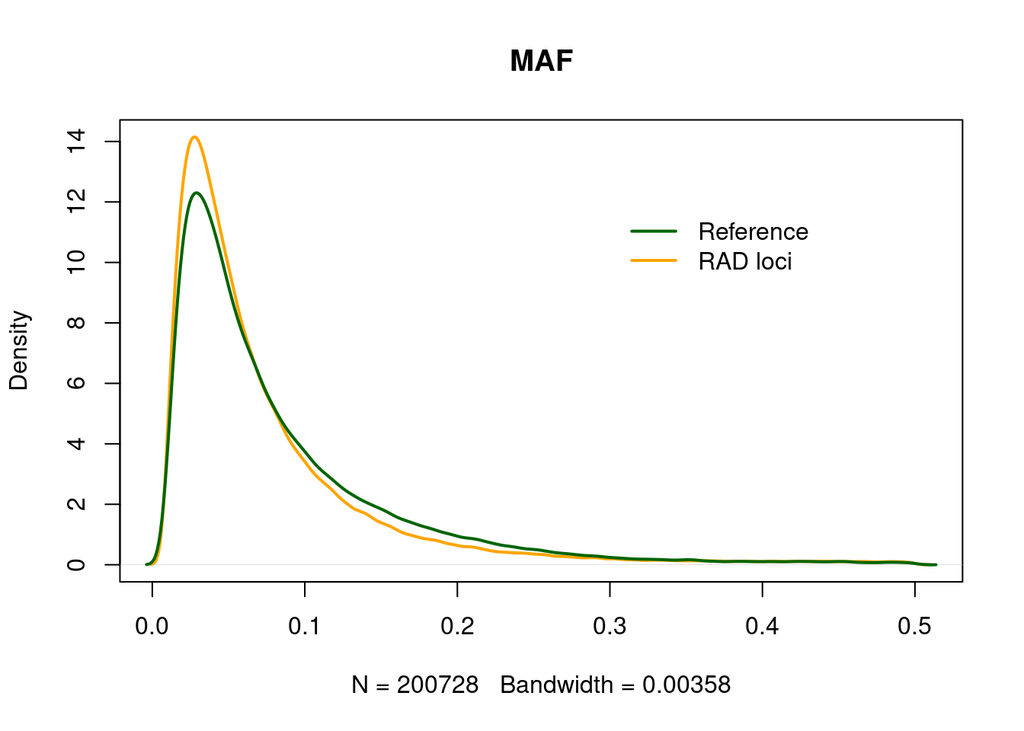

```r
refFreq <- read.table('ref/all.mafs.gz', header = TRUE)
radFreq <- read.table('rad/all.mafs.gz', header = TRUE)
plot(density(radFreq$knownEM),  lwd = 2, col = 'orange', main = 'MAF')
lines(density(refFreq$knownEM), lwd = 2, col = 'darkgreen')
legend(0.3, 12, c('Reference', 'RAD loci'), lwd = c(2, 2),
       col = c('darkgreen', 'orange'), bty = 'n')
```

## Estimates of coancestry

Note the setting of random seed with `-r`.

```bash
if [ ! -e ref/relatedness.txt ]; then
   if [ ! -e ref/freq.txt ]; then
      gunzip -c ref/all.mafs.gz | \
      cut -f 6 | \
      tail -n +2 > ref/freq.txt
   fi
   ngsrelate -g ref/all.glf.gz \
             -f ref/freq.txt \
             -n $(cat ref/all.list | wc -l) \
             -L $(cat ref/freq.txt | wc -l) \
             -O ref/relatedness.txt \
             -m 1 \
             -r 511 \
             -p 8 \
             1> ref/ngsrelate.log 2> ngsrelate.err &
fi

if [ ! -e rad/relatedness.txt ]; then
   if [ ! -e rad/freq.txt ]; then
      gunzip -c rad/all.mafs.gz | \
      cut -f 6 | \
      tail -n +2 > rad/freq.txt
   fi
   ngsrelate -g rad/all.glf.gz \
             -f rad/freq.txt \
             -n $(cat rad/all.list | wc -l) \
             -L $(cat rad/freq.txt | wc -l) \
             -O rad/relatedness.txt \
             -m 1 \
             -r 8031 \
             -p 8 \
             1> rad/ngsrelate.log 2> ngsrelate.err &
fi
wait
```

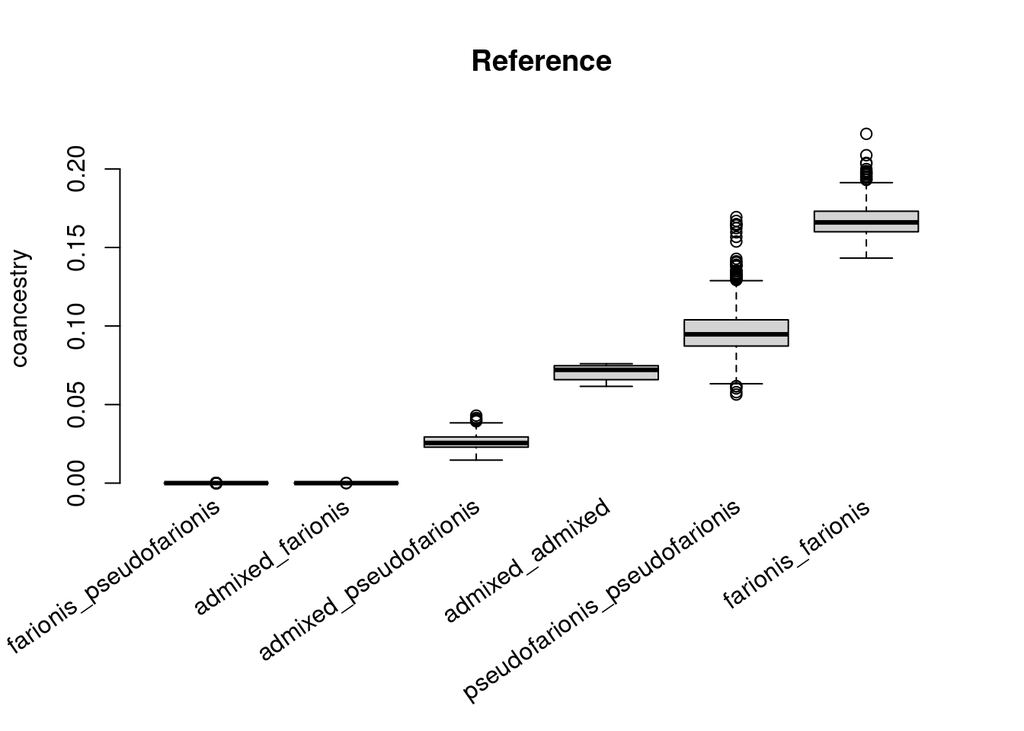

```r
library(ggplot2)
popstr <- read.table('../2024-10-05/summary.txt', header = TRUE)
popstr$pop <- factor('admixed',
                     levels = c('farionis', 'pseudofarionis', 'admixed'))
popstr[popstr$K2.1 > 0.95, 'pop'] <- 'pseudofarionis'
popstr[popstr$K2.2 > 0.95, 'pop'] <- 'farionis'
row.names(popstr) <- popstr$Sample

refsmp <- basename(scan('ref/all.list', what = 'character', quiet = TRUE))
refsmp <- gsub('.bam', '', refsmp)
radsmp <- basename(scan('rad/all.list', what = 'character', quiet = TRUE))
radsmp <- gsub('.bam', '', radsmp)
refrel1 <- read.table('ref/relatedness.txt', header = TRUE)
refrel1$a <- refsmp[refrel1$a + 1]
refrel1$b <- refsmp[refrel1$b + 1]
refrel1$pops <- sapply(
   1:dim(refrel1)[1],
   function(x) {
      paste(
         sort(
            as.character(
               c(popstr[refrel1[x, 'a'], 'pop'],
                 popstr[refrel1[x, 'b'], 'pop'])
            )
         ), collapse = '_')
   }
)
refrel1$Dist <- sapply(
   1:dim(refrel1)[1],
   function(x) {
      z <- as.numeric(unlist(strsplit(refrel1[x, 'X2dsfs'], ',')))
      0.5 * sum(z[c(2,4,5,6,8)]) + z[3] + z[7]
   }
)

radrel1 <- read.table('rad/relatedness.txt', header = TRUE)
radrel1$a <- radsmp[radrel1$a + 1]
radrel1$b <- radsmp[radrel1$b + 1]
radrel1$pops <- sapply(
   1:dim(radrel1)[1],
   function(x) {
      paste(
         sort(
            as.character(
               c(popstr[radrel1[x, 'a'], 'pop'],
                 popstr[radrel1[x, 'b'], 'pop'])
            )
         ), collapse = '_')
   }
)
radrel1$Dist <- sapply(
   1:dim(radrel1)[1],
   function(x) {
      z <- as.numeric(unlist(strsplit(radrel1[x, 'X2dsfs'], ',')))
      0.5 * sum(z[c(2,4,5,6,8)]) + z[3] + z[7]
   }
)

refrel1$pops <- factor(refrel1$pops,
                       levels = c('farionis_pseudofarionis',
                                  'admixed_farionis',
                                  'admixed_pseudofarionis',
                                  'admixed_admixed',
                                  'pseudofarionis_pseudofarionis',
                                  'farionis_farionis'))
par(mar = c(8, 4.1, 4.1, 2.1))
boxplot(refrel1$theta ~ refrel1$pops, axes = FALSE,
        ylab = 'coancestry', xlab = '', main = 'Reference')
axis(2)
text(1:length(levels(refrel1$pops)), -0.015, xpd = NA, srt = 35,
     labels = levels(refrel1$pops), adj = 0.99)
```

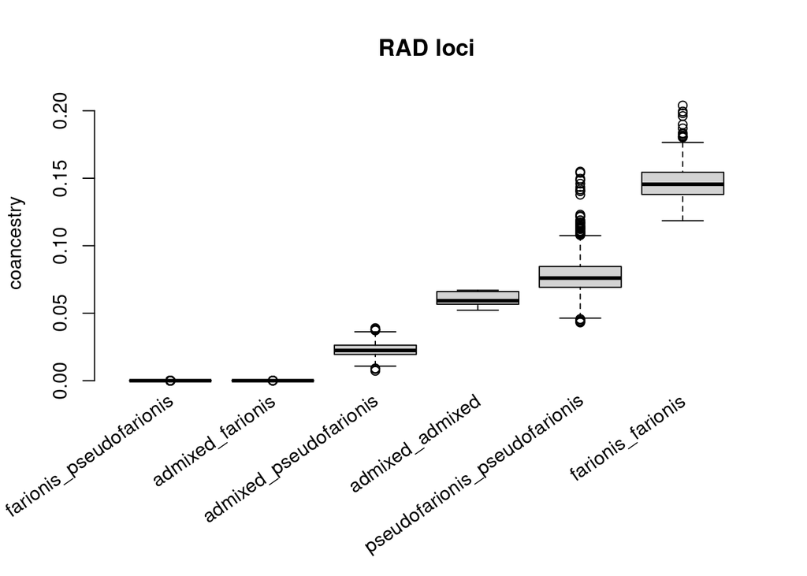

```r
radrel1$pops <- factor(radrel1$pops,
                       levels = c('farionis_pseudofarionis',
                                  'admixed_farionis',
                                  'admixed_pseudofarionis',
                                  'admixed_admixed',
                                  'pseudofarionis_pseudofarionis',
                                  'farionis_farionis'))
boxplot(radrel1$theta ~ radrel1$pops, axes = FALSE,
        ylab = 'coancestry', xlab = '', main = 'RAD loci')
axis(2)
text(1:length(levels(radrel1$pops)), -0.015, xpd = NA, srt = 35,
     labels = levels(radrel1$pops), adj = 0.99)
```

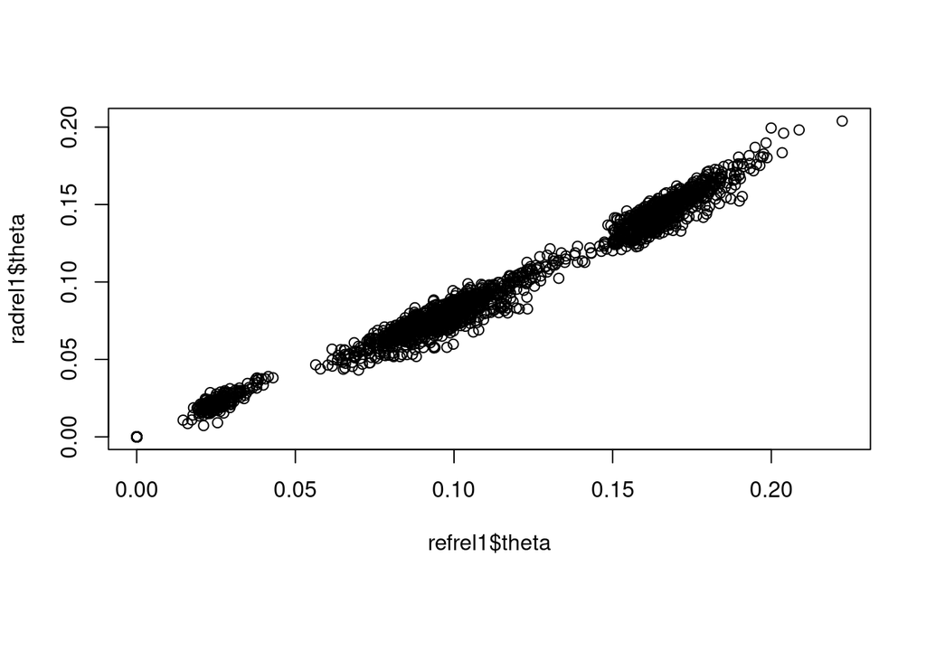

```r
plot(refrel1$theta, radrel1$theta)
```

As expected, the coefficient of coancestry is null between individuals from different populations.

## Sequence differences

The `ngsrelate` output includes the two-individuals 2D SFS of every comparison. They are 9 numbers reporting the fraction of all sites used in that comparison where each individual had each of the 3 possible genotypes in a biallelic site. From those numbers I can derive the fraction of sites where genotypes are different between the two individuals. Another measure of genetic distance is the expected difference upon randomly drawing one allele from each individual. So, a site where one is heterozygous and the other is homozygous would contribute 0.5 to the difference, which is the chance of picking the different alleles. The same is true if both are heterozygous. This is computed in the `Dist` column of both data frames.

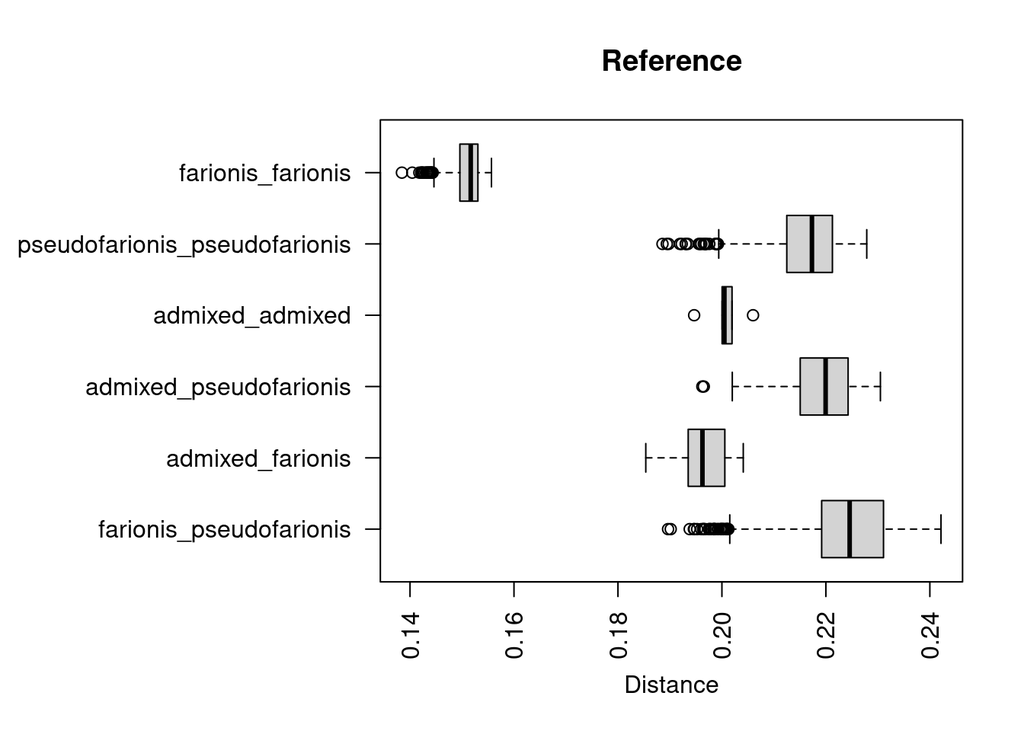

```r
par(mar = c(5.1, 13, 4.1, 2.1))
boxplot(refrel1$Dist ~ refrel1$pops, axes = TRUE, horizontal = TRUE,
        ylab = '', xlab = 'Distance', main = 'Reference', las = 2)
```

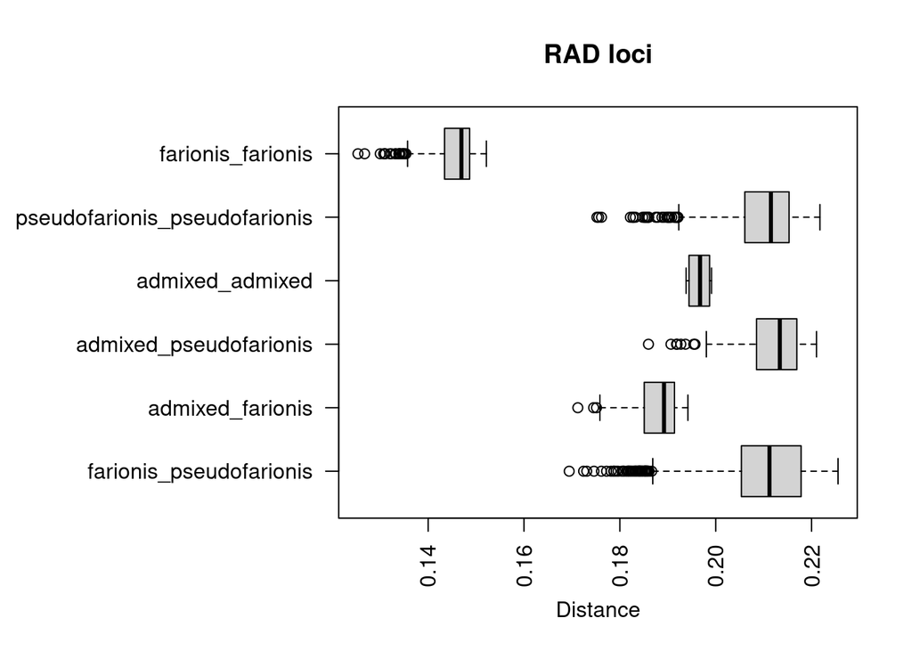

```r
boxplot(radrel1$Dist ~ radrel1$pops, axes = TRUE, horizontal = TRUE,
        ylab = '', xlab = 'Distance', main = 'RAD loci', las = 2)
```

It turns out that the distance among individuals from *C. pseudofarionis* is as large as the distance between *C. farionis* and *C. pseudofarionis*.

# References

Cockerham, C. C. 1971. “HIGHER ORDER PROBABILITY FUNCTIONS OF IDENTITY OF ALLELES BY DESCENT.” *Genetics* 69 (2): 235–46. https://doi.org/10.1093/genetics/69.2.235.

Hanghøj, K. and Moltke, I. and Andersen, P.A, and Manica, A. and Korneliussen, T.S. 2019. “Fast and Accurate Relatedness Estimation from High-Throughput Sequencing Data in the Presence of Inbreeding.” *GigaScience* 8 (5): giz034. https://doi.org/10.1093/gigascience/giz034.

Hedrick, Philip W., and Robert C. Lacy. 2014. “Measuring Relatedness Between Inbred Individuals.” *Journal of Heredity* 106 (1): 20–25. https://doi.org/10.1093/jhered/esu072.

Jacquard, A. 1970. *Structures Génétiques Des Populations*. Paris: Masson et Cie.

Lynch, M., and B. Walsh. 1998. *Genetics and Analysis of Quantitative Traits*. Sunderland: Sinauer Associates.